# Storm Event Economic and Human Costs in the US, 1961-2011

Gary A. Miller

Friday, August 22, 2014

### Synopsis

This report describes an analysis of data from the US NOAA’s [National Climactic Data Center](http://www.ncdc.noaa.gov/). The goal is to determine which types of storm events have caused the most damage to property and to human life.

### Data Processing

#### Loading and Pre-processing the Data

This code creates a folder for the data to be stored in if it does not already exist.

```r
if(!file.exists("data")) {
dir.create("data")
}
```

This code downloads the file into the Data folder. The Download Date is also recorded.

```r
FileUrl <- "http://d396qusza40orc.cloudfront.net/repdata%2Fdata%2FStormData.csv.bz2"
download.file(FileUrl,destfile="./data/StormData.csv.bz2")

DownloadDate <- format(Sys.Date(),"%B %d %Y")
```

These results are effective as of August 22 2014.

The next step is to read in the data.

```r
StormData <- read.csv(bzfile("./data/StormData.csv.bz2"))
```

Initial exploration shows that this is a fairly large dataset, which includes some attributes that are not useful to our specific analysis.

```r
dim(StormData)
```

```
## [1] 902297     37
```

```r
names(StormData)
```

```
##  [1] "STATE__"    "BGN_DATE"   "BGN_TIME"   "TIME_ZONE"  "COUNTY"
##  [6] "COUNTYNAME" "STATE"      "EVTYPE"     "BGN_RANGE"  "BGN_AZI"
## [11] "BGN_LOCATI" "END_DATE"   "END_TIME"   "COUNTY_END" "COUNTYENDN"
## [16] "END_RANGE"  "END_AZI"    "END_LOCATI" "LENGTH"     "WIDTH"
## [21] "F"          "MAG"        "FATALITIES" "INJURIES"   "PROPDMG"
## [26] "PROPDMGEXP" "CROPDMG"    "CROPDMGEXP" "WFO"        "STATEOFFIC"
## [31] "ZONENAMES"  "LATITUDE"   "LONGITUDE"  "LATITUDE_E" "LONGITUDE_"
## [36] "REMARKS"    "REFNUM"
```

My first transformation is to change the datatype of the Date column from factor to POSIXlt, and to extract just the year into a new column.

```r
StormData$BGN_DATE <- strptime(StormData$BGN_DATE,format="%m/%d/%Y")
StormData$BGN_YEAR <- format(StormData$BGN_DATE,"%Y")
```

This analysis is unavoidably shaped by the fact that much more data exists for events in more recent years. While data exists from events as far back as 1950, I removed data from 1960 and earlier.

```r
StormData <- StormData[StormData$BGN_YEAR>=1961,]
```

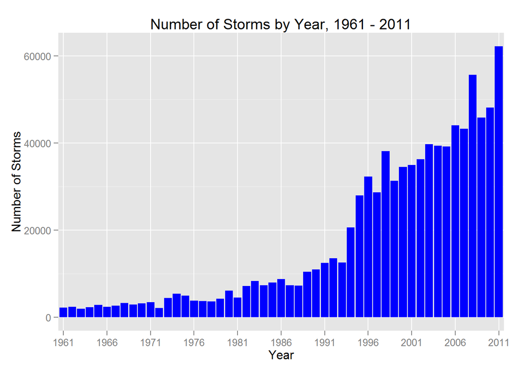

```r
library(ggplot2)
library(scales)

h <- ggplot(StormData,aes(x=BGN_YEAR))
h2 <- h + geom_histogram(fill="blue") +
    scale_x_discrete(breaks=seq(1961,2011,5)) +
     labs(x="Year",y="Number of Storms",
          title="Number of Storms by Year, 1961 - 2011")

print(h2)
```

The table below shows the number of storms identified as having taken place in each state. I removed those not placed in one of the fifty US states or in the District of Columbia.

```r
table(StormData$STATE)
```

```
##
##    AK    AL    AM    AN    AR    AS    AZ    CA    CO    CT    DC    DE
##  4391 22470  1879  3250 26675   257  6099 10710 20188  3258   437  1903
##    FL    GA    GM    GU    HI    IA    ID    IL    IN    KS    KY    LA
## 21838 24982  5337   306  2544 30682  4710 27970 21118 52052 21960 17066
##    LC    LE    LH    LM    LO    LS    MA    MD    ME    MH    MI    MN
##   274  1526   654  1347    70   262  5545  8116  4483     1 17639 23315
##    MO    MS    MT    NC    ND    NE    NH    NJ    NM    NV    NY    OH
## 34918 21930 14466 25164 14427 29476  3001  8034  6997  3133 20948 24718
##    OK    OR    PA    PH    PK    PM    PR    PZ    RI    SC    SD    SL
## 45443  4789 22071    28    23     1  3015    96   833 16988 21387     7
##    ST    TN    TX    UT    VA    VI    VT    WA    WI    WV    WY    XX
##     1 21456 82045  4107 21014   338  3837  3292 19552  9060  7250     2
```

```r
States <- c("AK","AL","AR","AZ","CA","CO","CT","DC","DE","FL","GA","HI","IA",
            "ID","IL","IN","KS","KY","LA","MA","MD","ME","MI","MN","MO","MS",
            "MT","NC","ND","NE","NH","NJ","NM","NV","NY","OH","OK","OR","PA",
            "RI","SC","SD","TN","TX","UT","VA","VT","WA","WI","WV","WY")

StormData <- StormData[StormData$STATE %in% States,]
```

Many variables in this dataset are not needed to answer these specific questions. I removed unnecessary columns.

```r
KeepCols <- c("EVTYPE","BGN_YEAR","FATALITIES","INJURIES","PROPDMG",
              "PROPDMGEXP","CROPDMG","CROPDMGEXP")

StormData <- StormData[,names(StormData) %in% KeepCols]
```

The titles given to each event (EVTYPE) have not been applied consistently. The next set of code creates a new EVLABEL column, sets ‘other’ as the default, and then assigns names based on a series of regular expression searches.

```r
InitEventTypeCount <- length(unique(StormData$EVTYPE))

StormData$EVTYPE <- toupper(StormData$EVTYPE)

StormData$EVLABEL <- "OTHER"
StormData$EVLABEL[grepl("FIRE",StormData$EVTYPE)] <- "FIRE"
StormData$EVLABEL[grepl("DUST",StormData$EVTYPE)] <- "DUST"
StormData$EVLABEL[grepl("FLOOD|SURGE",StormData$EVTYPE)] <- "FLOOD"
StormData$EVLABEL[grepl("HAIL",StormData$EVTYPE)] <- "HAIL"
StormData$EVLABEL[grepl("WIND",StormData$EVTYPE)] <- "HIGH WIND"
StormData$EVLABEL[grepl("WARM|HOT|DROUGHT|DRY|DRI|HEAT|HIGH",
                        StormData$EVTYPE)] <- "HEAT"
StormData$EVLABEL[grepl("COLD|FROST",StormData$EVTYPE)] <- "COLD"
StormData$EVLABEL[grepl("SNOW|BLIZZARD|WINT*MIX|WINT*STOR|ICE",
                        StormData$EVTYPE)] <- "SNOWSTORM"
StormData$EVLABEL[grepl("TORN|SPOUT|WALL|FUNNEL",
                        StormData$EVTYPE)]<-"TORNADO"
StormData$EVLABEL[grepl("HURRICANE|TYPHOON|TROP",
                        StormData$EVTYPE)]<-"HURRICANE"
StormData$EVLABEL[grepl("THUN|TSTM|MICROB|RAIN",
                        StormData$EVTYPE)] <- "THUNDERSTORM"

table(StormData$EVLABEL)
```

```
##
##         COLD         DUST         FIRE        FLOOD         HAIL
##         3851          576         4199        81637       285747
##         HEAT    HIGH WIND    HURRICANE        OTHER    SNOWSTORM
##        28345         4560          917        42827        22512
## THUNDERSTORM      TORNADO
##       332105        63211
```

```r
FinalEventLabelCount <- length(unique(StormData$EVLABEL))
```

There were initially 953 variations of event type spellings; the filtering above reduces that number to 12. Although the number of ‘Other’ responses remaining indicates that this process is inexact.

#### Analysis - Human Casualties

Combining fatality counts with injury counts yields a new column with a total number of casualties for each storm event. This is the ultimate measure of population impact for this analysis.

```r
StormData$CASUALTIES <- StormData$INJURIES + StormData$FATALITIES
```

Reshaping the data by both the fatality and injury variables allows for the human impact to be visualized with a stacked barplot later on in this report.

```r
library(reshape2)

StormCasualtyMelt <- melt(StormData,id="EVLABEL",measure.vars=
                        c("FATALITIES","INJURIES"))
```

#### Analysis - Property Damage

The documentation explains that the Property Damage Exponent corresponds to the degree of magnitude to apply to the amount given in the Property Damage column. I created a new ‘Multiplier’ column and populated it with the corresponding amount, with 1 as the default. I then multiplied the multiplier by the estimate to get a total damage amount.

```r
table(StormData$PROPDMGEXP)
```

```
##
##             -      ?      +      0      1      2      3      4      5
## 449155      1      8      5    216     25     13      4      4     28
##      6      7      8      B      h      H      K      m      M
##      4      5      1     39      1      6 409938      7  11027
```

```r
# Populate multiplier values based on code

StormData$PROPDMGMULTIPLIER <- as.numeric(1)

StormData$PROPDMGMULTIPLIER[StormData$PROPDMGEXP=="K"|
                            StormData$PROPDMGEXP=="k"|
                            StormData$PROPDMGEXP=="3"] <- 1000
StormData$PROPDMGMULTIPLIER[StormData$PROPDMGEXP=="4"] <- 10000
StormData$PROPDMGMULTIPLIER[StormData$PROPDMGEXP=="5"] <- 100000
StormData$PROPDMGMULTIPLIER[StormData$PROPDMGEXP=="M"|
                            StormData$PROPDMGEXP=="m"|
                            StormData$PROPDMGEXP=="6"] <- 1000000
StormData$PROPDMGMULTIPLIER[StormData$PROPDMGEXP=="7"] <- 10000000
StormData$PROPDMGMULTIPLIER[StormData$PROPDMGEXP=="8"] <- 100000000
StormData$PROPDMGMULTIPLIER[StormData$PROPDMGEXP=="B"] <- 1000000000

# Calculate total property damage

StormData$PROPDMGTOTAL <- StormData$PROPDMG * StormData$PROPDMGMULTIPLIER
```

The same process works for finding the amount of crop damage.

```r
table(StormData$CROPDMGEXP)
```

```
##
##             ?      0      2      B      k      K      m      M
## 595061      7     19      1      9     21 273399      1   1969
```

```r
# Populate multiplier values based on code

StormData$CROPDMGMULTIPLIER <- as.numeric(1)

StormData$CROPDMGMULTIPLIER[StormData$CROPDMGEXP=="2"] <- 100
StormData$CROPDMGMULTIPLIER[StormData$CROPDMGEXP=="K"|
                            StormData$CROPDMGEXP=="k"] <- 1000
StormData$CROPDMGMULTIPLIER[StormData$CROPDMGEXP=="M"|
                            StormData$CROPDMGEXP=="m"] <- 1000000
StormData$CROPDMGMULTIPLIER[StormData$CROPDMGEXP=="B"] <- 1000000000

# Calculate total crop Damage

StormData$CROPDMGTOTAL <- StormData$CROPDMG * StormData$CROPDMGMULTIPLIER
```

Now the total amount of property damage can be calculated by adding the property damage total to the crop damage total.

```r
StormData$TOTALDAMAGE <- StormData$PROPDMGTOTAL + StormData$CROPDMGTOTAL
```

Here’s a look at the final dataset before aggregating.

```r
head(StormData,5)
```

```
##        EVTYPE FATALITIES INJURIES PROPDMG PROPDMGEXP CROPDMG CROPDMGEXP
## 270   TORNADO          0        2      25          K       0
## 271   TORNADO          0        0     250          K       0
## 272   TORNADO          0        4      25          K       0
## 273 TSTM WIND          0        0       0                  0
## 274   TORNADO          0        0     250          K       0
##     BGN_YEAR      EVLABEL CASUALTIES PROPDMGMULTIPLIER PROPDMGTOTAL
## 270     1961      TORNADO          2              1000        25000
## 271     1961      TORNADO          0              1000       250000
## 272     1961      TORNADO          4              1000        25000
## 273     1961 THUNDERSTORM          0                 1            0
## 274     1961      TORNADO          0              1000       250000
##     CROPDMGMULTIPLIER CROPDMGTOTAL TOTALDAMAGE
## 270                 1            0       25000
## 271                 1            0      250000
## 272                 1            0       25000
## 273                 1            0           0
## 274                 1            0      250000
```

As with the casualty metric, I reshaped the data based on the totals for crop and property damage.

```r
StormEcoMelt <- melt(StormData,id="EVLABEL",measure.vars=
                         c("CROPDMGTOTAL","PROPDMGTOTAL"))
```

### Results

Tornados are far and away the storm event type that cause the most damage to human life.

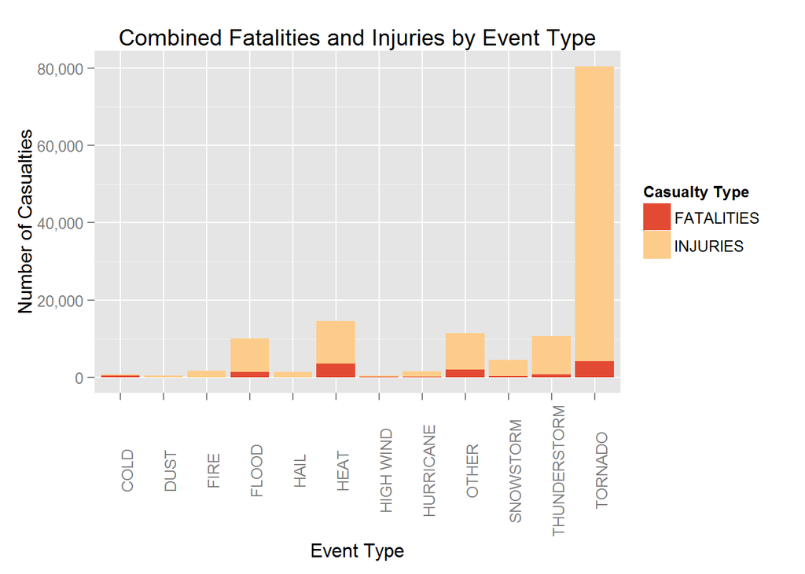

```r
c <- ggplot(StormCasualtyMelt,aes(x=EVLABEL,y=value,fill=variable))

c2 <- c + geom_bar(stat="identity") +
    labs(x="Event Type",y="Number of Casualties") +
    labs(title="Combined Fatalities and Injuries by Event Type") +
    scale_fill_manual(values=c("#e34a33","#fdcc8a"),name="Casualty Type") +
    scale_y_continuous(label=comma) +
    theme(axis.text.x = element_text(angle=90))

print(c2)
```

Floods have cause the most damage to property.

It’s also interesting to note the comparatively high percentage of damage that the heat / drought events have done to crops rather than other types of physical property.

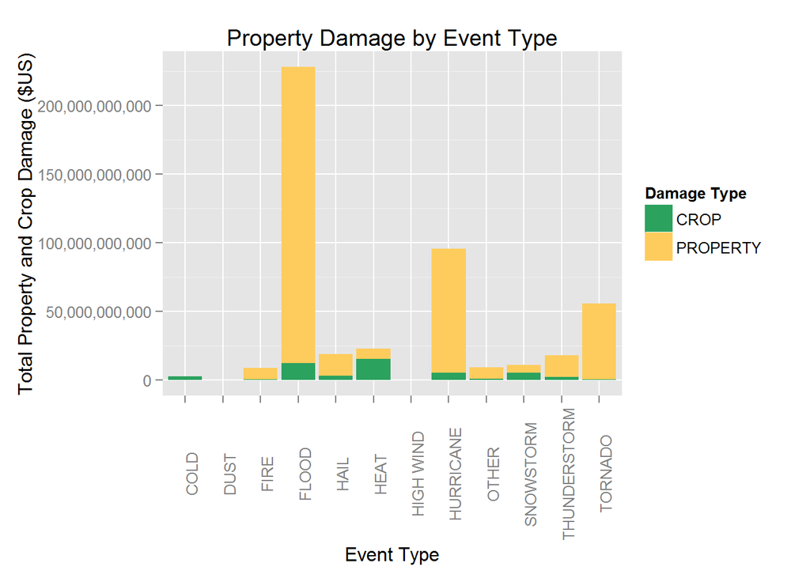

```r
p <- ggplot(StormEcoMelt,aes(x=EVLABEL,y=value,fill=variable))

p2 <- p + geom_bar(stat="identity") +
    labs(x="Event Type",y="Total Property and Crop Damage ($US)") +
    labs(title="Property Damage by Event Type") +
    scale_fill_manual(values=c("#2ca25f","#fecc5c"),name="Damage Type",
                      labels=c("CROP","PROPERTY")) +
    scale_y_continuous(label=comma) +
    theme(axis.text.x = element_text(angle=90))

print(p2)
```

### References

This analysis was completed as an assignment in [Reproducible Research](https://www.coursera.org/course/repdata), part of the Data Science Specialization offered by Johns Hopkins University via the Coursera platform.

The NCDC’s [Storm Center FAQ](https://d396qusza40orc.cloudfront.net/repdata%2Fpeer2_doc%2FNCDC%20Storm%20Events-FAQ%20Page.pdf) and the National Weather Service’s [documentation](https://d396qusza40orc.cloudfront.net/repdata%2Fpeer2_doc%2Fpd01016005curr.pdf) explain the definitions of each variable and how the data was compiled.

Additional data can be obtained from the Storm Events [database](http://www.ncdc.noaa.gov/stormevents).